# METABRIC: RNA SEQ CLUSTERING ANALYSIS

Sid Gurajala

1/1/2021

# INTRODUCTION

The Molecular Taxonomy of Breast Cancer International Consortium (METABRIC) dataset contains expression, clinical profiles, copy number variants and single nucleotide polymorphism data sequenced from over 2000 primary breast cancer tumors. Originally published in [Nature in 2012](https://pubmed.ncbi.nlm.nih.gov/22522925/), the METABRIC consortium has become one of the most comprehensive characteriziations of breast cancer genetics and physiology, and has feature extensively in publications as both a reference and a dataset of interest. Breast cancer is currently the second most common cancer for women in the US, and in 2020 over 250,000 new cases of breast cancer were reported with over 40,000 people dying over the course of the disease. It is estimated that about 1 in 8 US women will develop breast cancer over her lifetime. The importance of understanding the underlying genetics of breast cancer in patients therefore cannot be understated. This project seeks to apply two types of popular RNA-seq analyses to METABRIC data to better understand expression profiles in patients. Both kmeans clustering and hierarchical clustering will be used to explore how suites of genes partition themselves in accordance with expression profiles.

[Metabric data can be found here](https://ega-archive.org/studies/EGAS00000000098)

# PCA

One of the biggest challenges in dealing with biological data sets is the large number of dimensions, which can often hinder computationally intensive analyses. A means to pare down data into essential parts that are representative of the variance found in the whole data set is PCA, or prinicipal component analysis. PCA is a linear transformation orthogonal to current data, and seeks to assign data to principal components where the the first principal component captures the most variance from the original data set and further components have lower and lower values of explained variance. I have applied PCA to RNA-seq data to see if dimensionality reduction can be achieved.

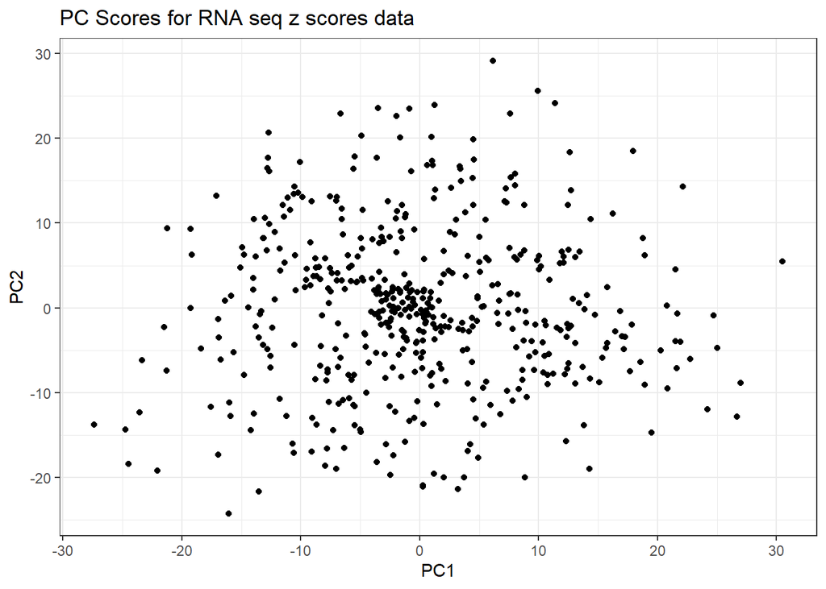

```r
#PCA

#drop nas and invert so genes are rows
metabric_mx <- as.matrix(na.omit(metabric_df[, 1:491]))
colnames_mt_mx <- metabric_mx[, 1]
metabric_mx <- t(metabric_mx[, 2:491])
#creating pca object
metabric_pca <- prcomp(metabric_mx[2:490, ], scale = TRUE)

#exploring PCA visually
library(ggplot2)
pc_scores <- metabric_pca$x
pc_scores_plot <- as.data.frame(pc_scores) %>%
                    ggplot(aes(x = PC1, y = PC2)) +
                    geom_point() +
                    labs(title = "PC Scores for RNA seq z scores data") +
                    theme_bw()

pc_scores_plot
```

While the Principal component scores for these data show quite a lot of variance, there is some structure to the data. While PCA may not be entirely useful for this data, you can see a few clusters around the middle of the plot. Further visualizations should help elucidate the efficiency for PCA in reducing the dimensions of this data set.

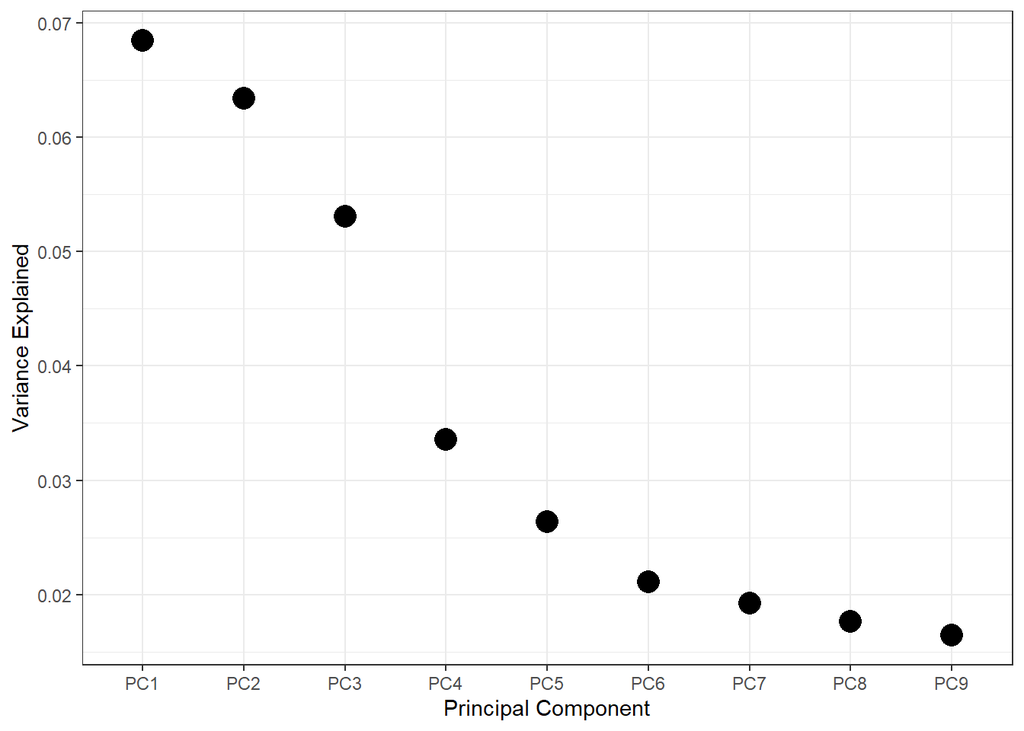

```r
#creating biplot
library(ggbiplot)
metabric_biplot <- ggbiplot(metabric_pca) +
                    theme_bw() +
                    scale_color_manual(labels = c("Died from Disease",
                                                  "Living"),
                                       values = c("darkorange", "purple"))
#drops text labels crowding graph
metabric_biplot$layers[[3]] <- NULL

#creating screeplot df
var_explained <- (metabric_pca$sdev) ^ 2 / sum((metabric_pca$sdev) ^ 2)
var_explained <- var_explained[1:9]
screeplot_pca_df <- data.frame(PC = paste0("PC", 1:9),
                               Variance_Explained = (var_explained))
#making screeplot
screeplot_pca <- screeplot_pca_df %>%
                  ggplot(aes(x = PC, y = Variance_Explained)) +
                  geom_point(size = 5) +
                  labs("Screeplot of PC 1 - 10 for METABRIC expression data",
                       x = "Principal Component",
                       y = "Variance Explained") +
                  theme_bw()

screeplot_pca
```

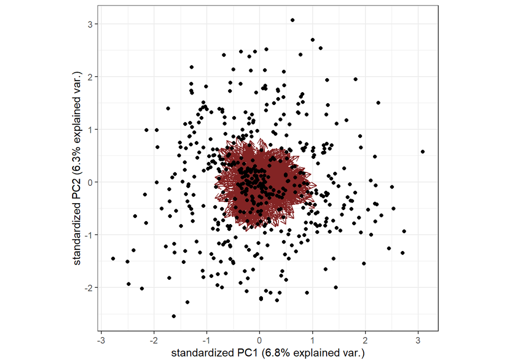

```r
#display biplot
metabric_biplot
```

Both of these plots demonstrate that PCA may not be an effective means of decomposition for this data. The biplot shown states that both principal components explain relatively little of the data (6.8% for PC1 and 6.3% for PC2). The screeplot also shows that additional principal components do not effectively explain variance in the dataset. While PCA has the potential to be an effective tool for increasing the manageability of the size of data sets, these visualizations make it clear that it cannot be used as a tool for these specific data.

# K MEANS CLUSTERING - MODEL SELECTION

K means clustering is to date one of the most popular unsupervised machine learning algorithims. It uses a predetermined number (k) clusters to partition data into groups more homogenous than initial data. Data points are assigned to clusters by calculating by reducing the in cluster sum of squares, the squared euclidean distance between each data point and the centroid (the center of each cluster around which other data points are organized). The algorithm starts with randomly selected centroids and then iterates calculations to locate the optimal position for the centroids. K means clustering seeks to minimize the distance within a cluster while maximizing the distance between clusters. The major requirement of k means clustering is beforehand knowledge of the optimal number of clusters before using the algorithm to partition data. While selecting the number of clusters is more an art than a science, there are several computational tools that can help visualize k means clustering and inform decision making.

## SSE

The Sum of Squared Errors is a measurement of the distance of data points from the nearest cluster. Minimizing SSE can help determine the optimal number of clusters and thereby maximize the k means algorithm’s efficiency in data partioning. The formula for SSE is:
$$SSE = \sum_{i = 1}^{n} (X_i - \bar{X}) ^ 2$$
Below I calculate the SSE for k = 2 to k = 20 and visualize the results to determine the optimal k value.

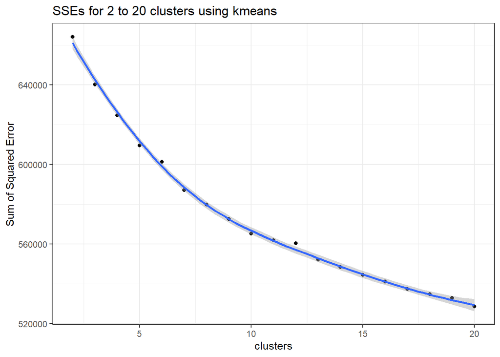

```r
#for loop calculating sse for k 1 to 20 clusters
metabric_sse <- vector()
for (i in 2:20) {
  metabric_sse[i] <- sum(kmeans(metabric_mx[2:490, ], centers = i)$withinss)
}

#creates df of metabric sse values
metabric_sse_df <- na.omit(data.frame(sse = metabric_sse,
                                       clusters = 1:20))
#Creates SSE plot
sse_plot <- ggplot(metabric_sse_df, aes(x = clusters, y = sse)) +
              geom_point() +
              geom_smooth() +
              theme_bw() +
              labs(title = "SSEs for 2 to 20 clusters using kmeans",
                    y = "Sum of Squared Error")
sse_plot
```

The key to this visualization is to look for the “elbow:” the point at which the addition of more clusters doesn’t significantly reduce the sum of squared error. Based on this plot, the elbow appears to be around 7-9 clusters. Further tests should better elucidate the best number of clusters.

## Average Silhouette Width

The silhouette width of kmeans clusters measures the euclidean distance between two clusters. The objective of silhouette width measurements is to maximize the distance, resulting in a high silhouette coefficient. This in turn results in distinct clusters with little overlap. Below I have measured the average silhouette width for k = 2 to k = 20 clusters.

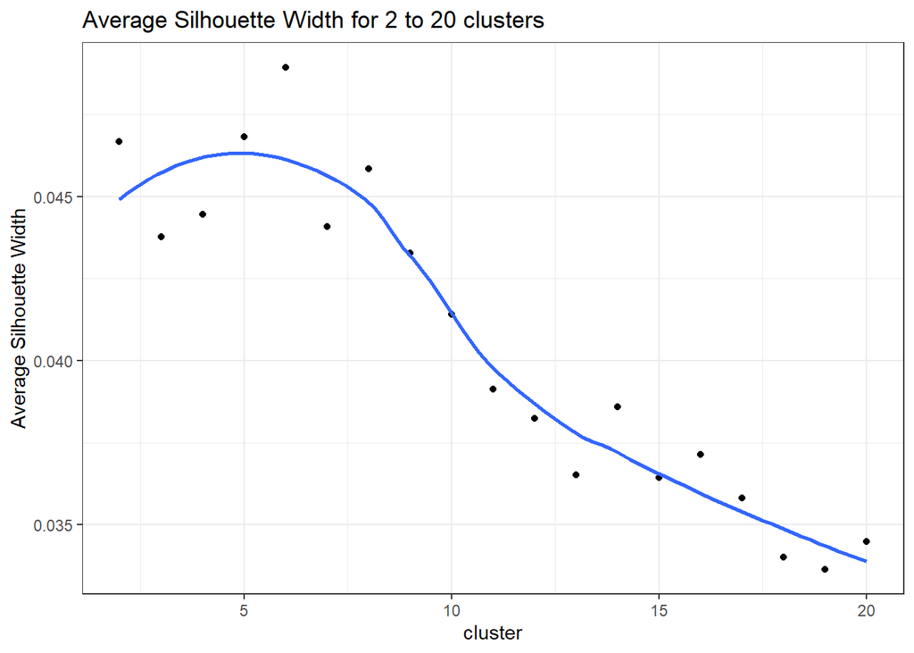

```r
library(cluster)
#for loop calculating silhouette width for 1 to 20 clusters
metabric_sil <- vector()
for (i in 2:20) {
  k_one_to_twenty <- kmeans(metabric_mx[2:490, ], centers = i, nstart = 25,
                            iter.max = 20)
  ss <- silhouette(k_one_to_twenty$cluster, dist(metabric_mx[2:490, ]))
  metabric_sil[i] <- mean(ss[, 3])
}
#creates silhoutte width df
metabric_sil_df <- na.omit(data.frame(AvgSilhouetteWidth = metabric_sil,
                                      cluster = 1:20))
#plots silhouette width
sil_plot <- ggplot(metabric_sil_df, aes(x = cluster, y = AvgSilhouetteWidth)) +
              geom_point() +
              geom_smooth(se = FALSE) +
              labs(title = "Average Silhouette Width for 2 to 20 clusters",
                   y = "Average Silhouette Width") +
              theme_bw()
sil_plot
```

The silhouette plot indicates that six clusters is the optimal number of clusters for this analysis, with a range between 5 and 8 clusters all having high silhouette values.

## Calinski-Harabasz Criterion

The Calinksi-Harabasz index is rooted in the sum of squared error within and between clusters. Maximizing the index involves using iterative kmeans clustering algorithms, and I carried out the Calinksi-Harabasz over 100 iterations from k = 2 to k = 20 clusters.

```r
## Calinksy Criterion
library(vegan)
```

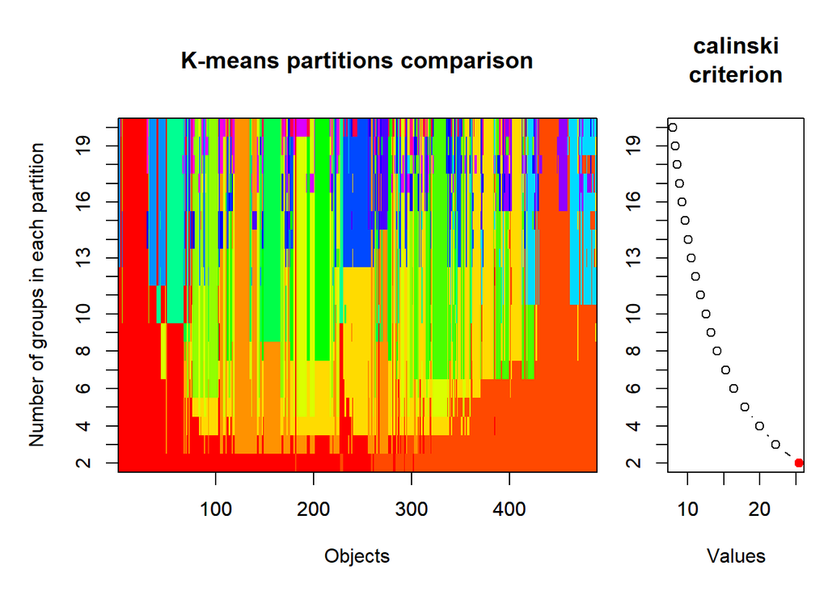

```r
#calculates calinsky index for 1 to 20 clusters
metabric_calinksi <- cascadeKM(metabric_mx[2:490, ], 2, 20, iter = 100)
#Creates heatmap and index plot
plot(metabric_calinksi, sortg = TRUE, grpmts.plot = TRUE)
```

While the max Calinski-Harabasz index value is at k = 2 clusters, two clusters often result in k means cluster models that are too generalizable and segregates points into clusters they may not be homogenous with. Index values between k = 3 to k = 6 are also relatively high, pointing to a k value between these two numbers as a good choice for kmeans cluster analysis.

## Gap Statistic

The gap statistic informs on the best cluster number by comparing the log within cluster sum of squares with the expected log sum of squares under a null reference distribution. The optimal number of clusters is selected by maximizing the gap between the data set’s within cluster sum of squares and the null reference distribution. Below I have carried out this analysis with k = 1 to k = 20 clusters over 100 iterations.

```r
## Gap Statistic
set.seed(13)
#calculates Gap statistics
metabric_gap <- clusGap(metabric_mx[2:490, ], kmeans, 20, B = 100,
                        verbose = interactive())
```

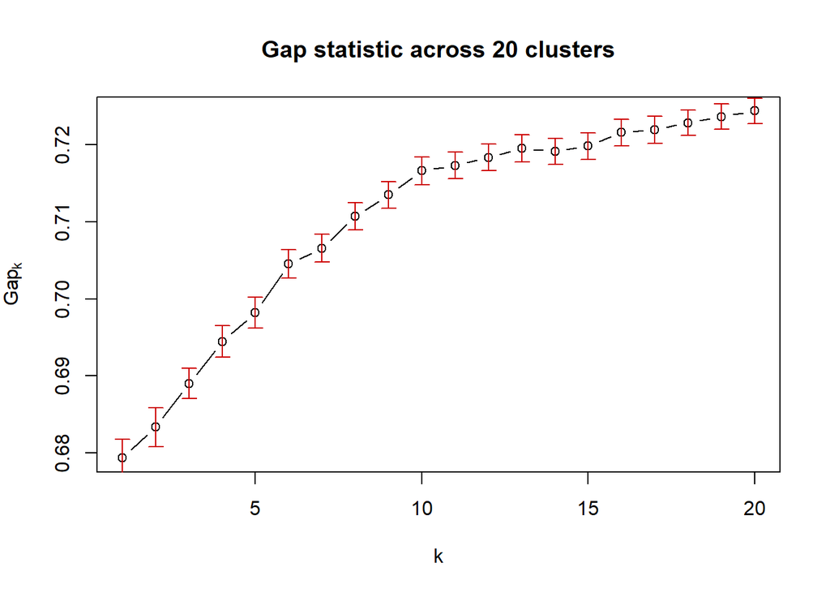

```r
#plot for gap statistics
plot(metabric_gap, main = "Gap statistic across 20 clusters")
```

While the max gap statistic value is at k = 20, this model would likely be far too specific and would lack robustness with other data sets. The inflection point of this plot seems to be at around 6-8 clusters, with values around this range also having a high gap value. The cumulative suggestion of these analyses suggests that anywhere between 4 and 7 clusters would be appropriate for these data.

# K MEANS CLUSTERING - CLUSTER ANALYSIS

Given previous tests, the optimal number of clusters seems to be around 4. Below I have arranged several different analyses of clustered expression data, starting with partioning with k = 4.

```r
# Clustering
set.seed(20)
kClust <- kmeans(metabric_mx[2:490, ], centers = 4,
                 nstart = 1000, iter.max = 20)
metabric_clust <- kClust$cluster
```

## Calculating Centroids and Analyzing Correlations

An after the fact method to validate cluster number selection is to calculate cluster centroids and correlate them with each other. Cluster centroids displaying a high degree of correlation ( > 0.85) is suggestive of unspecific clusters with similar profiles in euclidean space. Below I have made a function to calculate centroids and have computed correlations between them.

```r
## Finding centroids; takes col means
cluster_centroid <- function(num, data, clusters) {
  x <- (clusters == num)
  colMeans(data[x, ])
}

#calculates centroids
metabric_clust_centroids <- sapply(levels(factor(metabric_clust)),
                                   cluster_centroid,
                                   metabric_mx[2:490, ],
                                   metabric_clust)
#calculates correlation between centroids
cor(metabric_clust_centroids)
```

```
##             1           2          3          4
## 1  1.00000000 -0.07852618 -0.2675972 -0.5309844
## 2 -0.07852618  1.00000000 -0.1373369 -0.3353274
## 3 -0.26759719 -0.13733692  1.0000000 -0.2209434
## 4 -0.53098443 -0.33532745 -0.2209434  1.0000000
```

## Visualizing Cluster Expression for 6 patients

A point of interest is understanding how these clusters behave across different conditions. Oftentimes this is analyzed between two different treatment groups or time points within an experiment. In the case of these data it is valuable to tie the difference between cluster expression to the variance found in the population of breast cancer patients. I have carried this out below using six separate patients.

```r
#adding gene name as column and cluster# to metabric_mx_2
metabric_mx_2 <- as.data.frame(metabric_mx[2:490, ])
names_mx_2 <- rownames(metabric_mx_2)
rownames(metabric_mx_2) <- seq(1:489)
metabric_df_2 <- metabric_mx_2 %>%
                  mutate(gene = names_mx_2) %>%
                  mutate(cluster = as.vector(metabric_clust))
#Extracting expression data for 6 patients
patient_col_names <- c("Expression", "gene", "cluster", "Patient")
patient1_df <- metabric_df_2 %>%
  select(1418, gene, cluster) %>%
  mutate(patient = "Patient 1")
colnames(patient1_df) <- patient_col_names
```

Using similar methods for Patients 2 through 6, I compiled the expression per cluster into patients_df and plot the expression per cluster per patient below.

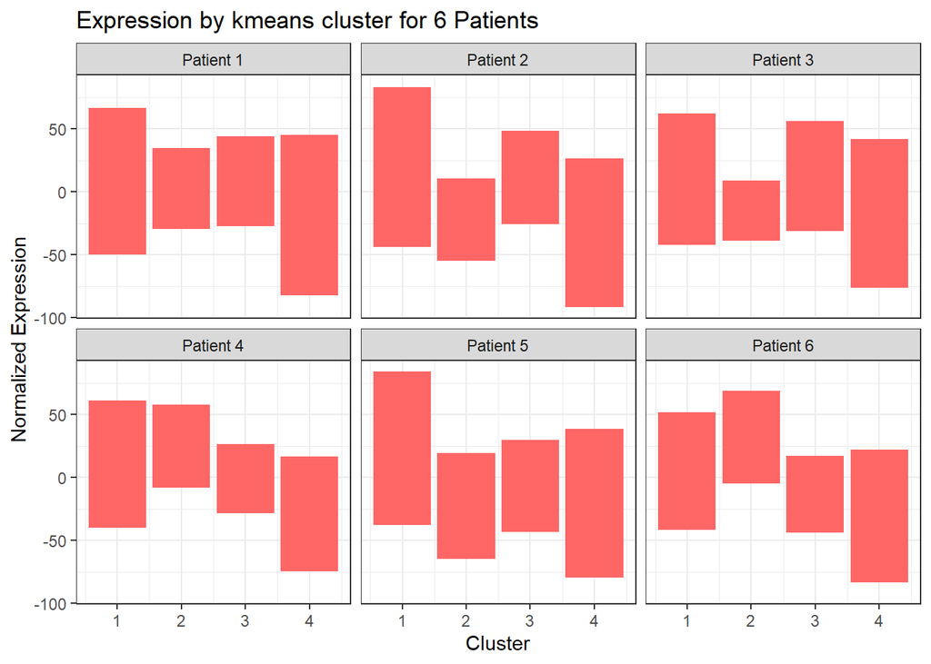

```r
#combining patient dfs
patientsdf <- rbind(patient1_df, patient2_df, patient3_df,
                     patient4_df, patient5_df, patient6_df)
#making plot
kmeans_patients <- ggplot(data = patientsdf, aes(x = cluster, y = Expression)) +
                    geom_bar(stat = "identity", fill = "#FF6666") +
                    facet_wrap(~Patient) +
                    labs(title = "Expression by kmeans cluster for 6 Patients",
                         x = "Cluster",
                         y = "Normalized Expression") +
                    theme_bw()

kmeans_patients
```

This figure displays the variation in expression patterns between clusters. By and large, patient cluster expression profiles are similar and follow general patterns; with cluster 4 having the most negative normalized expression and cluster 1 having the highest normalized expression. The differences between these clusters reflect population variances, demonstrating how differences in tumor types, individual physiology and genetics is shown in clustered expression profiles.

## Extracting Core Genes

```r
library(reshape)
#melt data to long form
metabric_clust_melt <- melt(metabric_clust_centroids)
#assign colnames
colnames(metabric_clust_melt) <- c("sample", "cluster", "value")
#subset melted data frame
metabric_core_1 <- metabric_clust_melt %>%
                    filter(cluster == "1")
#assign metabric_mx with only genes
metabric_mx_2 <- metabric_mx[2:490, ]

#pull out cluster 1
metabric_clust_1 <- metabric_mx_2[metabric_clust == 1, ]
#function that calculates correlation score for cluster 1
correlation_score_1 <- function(n) {
  cor(n, metabric_core_1$value)
}
#calculates cluster1 scores
clust1_scores <- apply(metabric_clust_1, 1, correlation_score_1)
#identifies top 5 highest correlated genes
core_clust_1_genes <- tail(sort(clust1_scores))
```

Using similar methods I determined core genes for clusters 2 - 4 and assembled into the table seen below.

```r
#Combining core genes from clusters 1 through 4
core_genes_df <- data.frame("cluster 1 genes" = names(core_clust_1_genes),
                            "cluster 1 scores" = core_clust_1_genes,
                            "cluster 2 genes" = names(core_clust_2_genes),
                            "cluster 2 scores" = core_clust_2_genes,
                            "cluster 3 genes" = names(core_clust_3_genes),
                            "cluster 3 scores"= core_clust_3_genes,
                            "cluster 4 genes" = names(core_clust_4_genes),
                            "cluster 4 scores" = core_clust_4_genes)
#assigning row names of 1 to 6 for genes
rownames(core_genes_df) <- c(1:6)
#display core_genes_df
core_genes_df
```

```
##   cluster.1.genes cluster.1.scores cluster.2.genes cluster.2.scores
## 1           casp6        0.5219486          pdgfrb        0.7376668
## 2             ran        0.5256174          col6a3        0.7475644
## 3            pms2        0.5551705           prkd1        0.7705461
## 4           cyb5a        0.5679322          pdgfra        0.7755751
## 5            snw1        0.5794297           lama2        0.7836099
## 6           eif4e        0.5842233          tgfbr2        0.8277333
##   cluster.3.genes cluster.3.scores cluster.4.genes cluster.4.scores
## 1            cdk1        0.6621336            tsc2        0.6194006
## 2           aurka        0.6706922            bap1        0.6311837
## 3          cdc25a        0.6738268            tnk2        0.6365578
## 4            e2f3        0.6853154          setd1a        0.6506032
## 5           ccne1        0.7478923          map2k2        0.6588908
## 6           chek1        0.7912385           kmt2c        0.6928768
```

Understanding how core genes align with kmeans cluster cores can help cut down on noise in clusters - especially helping distinguish between genes that help define a cluster well and genes that clutter a cluster with low correlation scores. Extracting these core genes also enables identification of genes of interest that resemble each other in expression profiles. This opens up an avenue of possibilities connecting machine learning with biological pathways and systems.

# HIERARCHICAL CLUSTERING

Hierarchical clustering is a seperate unsupervised clustering algorithm that does not rely on a priori knowledge of optimal cluster number. It operates by building a hierarchy of clusters instead of partioning data into a predefined number of clusters, with the optimal number of clusters determined a posteriori with the help of dendrogram like tree visualizations. The hierarchical clustering algorithm also uses distance measurement between data points, in this case the normalized expression scores of genes. Below I use R’s inbuilt hierarchical clustering function hclust() and visualize.

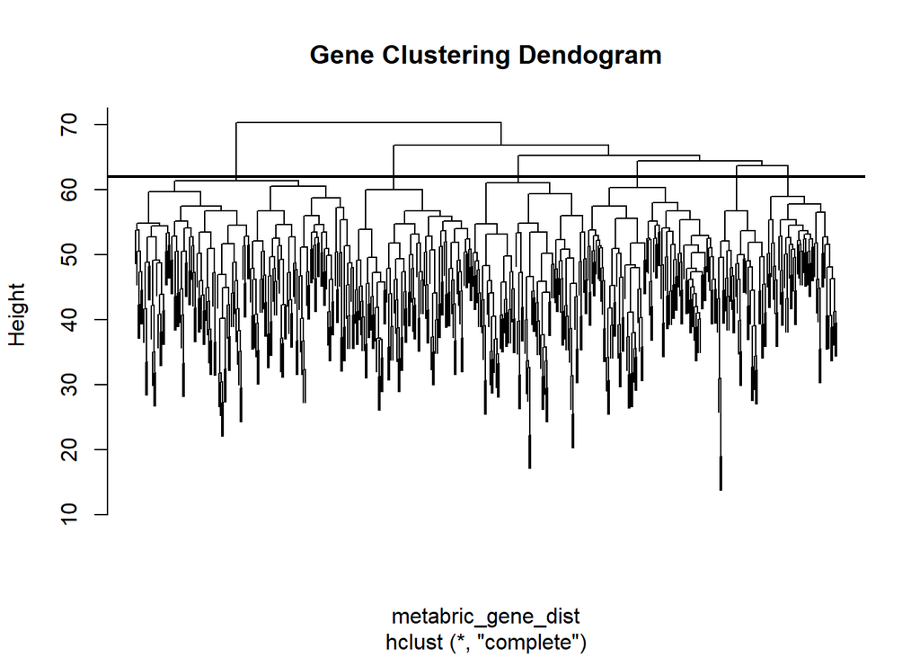

```r
#HIERARCHICAL CLUSTERING

#calculating gene distance for each row
metabric_gene_dist <- dist(metabric_mx_2)
#using hclust function on gene distance
metabric_hclust <- hclust(metabric_gene_dist, method = "complete")
#dendrogram of genes clustered
plot(metabric_hclust, labels = FALSE, main = "Gene Clustering Dendogram")
abline(h = 62, lwd = 2)
```

The line represents an eyeballed optimal number of clusters, which I have determined are around 6 clusters. This number can be used to partition the expression data for further analyses.

## Cluster Expression Profiles for 6 Patients

A similar analysis to the K means clustering can be carried out with hierarchical clustered data. The dendrogram of hierarchically clustered METABRIC data suggests that six clusters would be appropriate. Below I use R’s cutree() function to forcibly partition data and extract expression data per cluster for six patients.

```r
#seperating data by cluster and turning it into a tibble
metabric_hc_clusters <- as.vector(cutree(metabric_hclust, k = 6))
#adding gene name as column and cluster# to metabric_mx_2
metabric_df_3 <- as.data.frame(metabric_mx_2) %>%
                    mutate(gene = names_mx_2) %>%
                    mutate(cluster = metabric_hc_clusters)
#Extracting expression data for 6 patients
patient_1_df <- metabric_df_3 %>%
                  select(1418, gene, cluster) %>%
                  mutate(patient = "Patient 1")
colnames(patient_1_df) <- patient_col_names
```

Using similar methods I calculated expression data per cluster for patients 2 through 6 and display the results in the bar plot below.

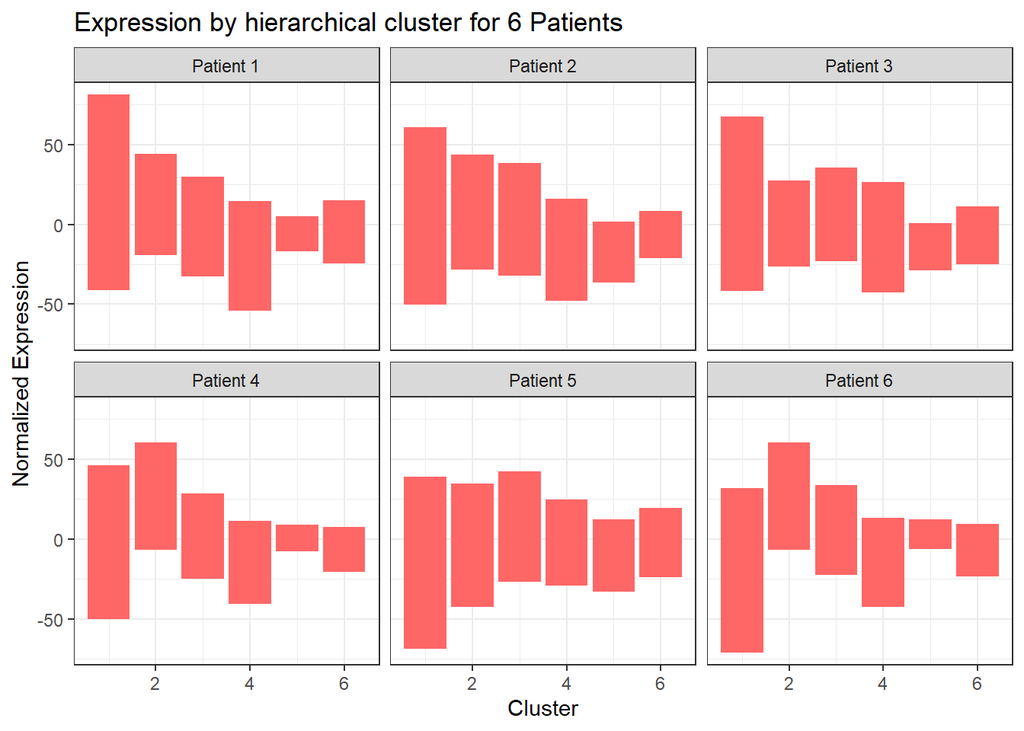

```r
#combining patient dfs
patients_df <- rbind(patient_1_df, patient_2_df, patient_3_df,
                     patient_4_df, patient_5_df, patient_6_df)
#making plot
patient_plot <- ggplot(data = patients_df, aes(x = cluster, y = Expression)) +
                  geom_bar(stat = "identity", fill = "#FF6666") +
                  facet_wrap(~Patient) +
                  labs(
                    title = "Expression by hierarchical cluster for 6 Patients",
                    x = "Cluster",
                    y = "Normalized Expression") +
                  theme_bw()

patient_plot
```

## Heatmap Visualization

One of the most popular ways to visualize RNA-seq data is through heatmap based hierarchical clustering. This provides an accessible, distinctive way to distinguish clusters within expression data as well as an attractive foundation for future analyses connecting genes with correlated profiles. Below I’ve rendered a heatmap with hierarchically clustered expression data.

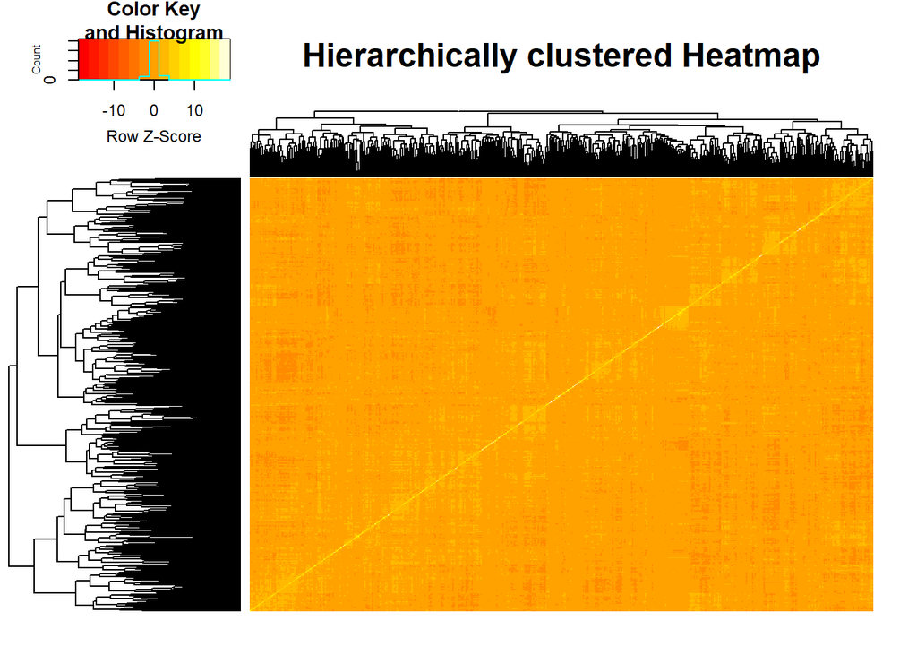

```r
#Making heatmap
library(gplots)
hc_dist <- cor(t(metabric_mx_2), method = "pearson")
hc_hr <- hclust(as.dist(1 - hc_dist), method = "complete")

#heatmap.2 of hc_dist
heatmap.2(hc_dist,
          Rowv = as.dendrogram(hc_hr),
          Colv = as.dendrogram(hc_hr),
          scale = "row",
          margins = c(2,2),
          cexCol = 0.7,
          labRow = FALSE,
          labCol = FALSE,
          main = "Hierarchically clustered Heatmap",
          trace = "none")
```

This heatmap is a convenient visualization of what has been observed earlier within the dendogram - namely multiple small clusters of expression profiles that cosegregate with other clusters to fit within a larger tree. This can be seen specifically along the top right hand corner of the heatmap, which designates several clusters of interest side by side.

# CONCLUSION

These analyses represent a relevant and powerful intersection between popular unsupervised machine learning algorithms and genetic expression profiles underlying a pertinent data set exploring a real world problem. The data gathered via clustering analyes can often be used to inform our knowledge of biological systems, and can reveal connections between suites of genes that humans would never think to draw. Expanding on these algorithms and adjusting modeling to better suit the types of data encountered can provide powerful insights into everything from gene regulation to disease outcome.